# Digits

## Contents

1. Imports
2. Preporecessing
   - Downloading The Dataset
   - Loading The Dataset
   - Visualizing The Dataset
   - Preparing The Dataset
3. Modeling
   - Non-Nueral Network Models
     - Linear Model
     - Random Forest
     - Gradient Boost Classifier
     - Extra Tree Classifier
     - XGBoost
   - Nueral Network Models
     - A Simple NN

## Imports

```python
import zipfile
import datetime
import os
import pandas as pd
import matplotlib.pyplot as plt
import seaborn as sns
from sklearn.metrics import accuracy_score, confusion_matrix, classification_report
from sklearn.model_selection import train_test_split
from sklearn.preprocessing import OneHotEncoder
from life_saving_tools.Notification import Notification
from sklearn.linear_model import LogisticRegression
from sklearn.ensemble import RandomForestClassifier, ExtraTreesClassifier, GradientBoostingClassifier
from xgboost import XGBClassifier

import tensorflow as tf
import tensorflow.keras.layers as tfl
from tensorflow.keras.models import Sequential
from tensorflow.keras.callbacks import ModelCheckpoint, EarlyStopping, TensorBoard
from warnings import filterwarnings
filterwarnings("ignore")
from life_saving_tools.ML import Modeling
```

## Preprocessing

### Downloading the dataset

> You'll need to have kaggle authentification files in your laptop for the cell below to work.

```python
! kaggle competitions download -c digit-recognizer
```

```
Downloading digit-recognizer.zip to c:\Users\harik\Desktop\Portfolio\MNIST_Digits
```

### Extracting the dataset

```python
zipref = zipfile.ZipFile('digit-recognizer.zip', 'r')
zipref.extractall()
```

### Loading The Dataset

```python
df = pd.read_csv('train.csv')
test_df = pd.read_csv('test.csv')
```

```python
df.head()
```

|  | label | pixel0 | pixel1 | pixel2 | pixel3 | pixel4 | pixel5 | pixel6 | pixel7 | pixel8 | ... | pixel774 | pixel775 | pixel776 | pixel777 | pixel778 | pixel779 | pixel780 | pixel781 | pixel782 | pixel783 |
| --- | --- | --- | --- | --- | --- | --- | --- | --- | --- | --- | --- | --- | --- | --- | --- | --- | --- | --- | --- | --- | --- |
| 0 | 1 | 0 | 0 | 0 | 0 | 0 | 0 | 0 | 0 | 0 | ... | 0 | 0 | 0 | 0 | 0 | 0 | 0 | 0 | 0 | 0 |
| 1 | 0 | 0 | 0 | 0 | 0 | 0 | 0 | 0 | 0 | 0 | ... | 0 | 0 | 0 | 0 | 0 | 0 | 0 | 0 | 0 | 0 |
| 2 | 1 | 0 | 0 | 0 | 0 | 0 | 0 | 0 | 0 | 0 | ... | 0 | 0 | 0 | 0 | 0 | 0 | 0 | 0 | 0 | 0 |
| 3 | 4 | 0 | 0 | 0 | 0 | 0 | 0 | 0 | 0 | 0 | ... | 0 | 0 | 0 | 0 | 0 | 0 | 0 | 0 | 0 | 0 |
| 4 | 0 | 0 | 0 | 0 | 0 | 0 | 0 | 0 | 0 | 0 | ... | 0 | 0 | 0 | 0 | 0 | 0 | 0 | 0 | 0 | 0 |

5 rows × 785 columns

```python
df.shape, test_df.shape
```

```
((42000, 785), (28000, 784))
```

So, we have 42000 training images and 28000 testing images.

### Extracting labels and images

```python
X = df.iloc[:, 1:].values
y = df.iloc[:,0].values
y = y.reshape(-1, 1)
```

### Visualizing The Dataset

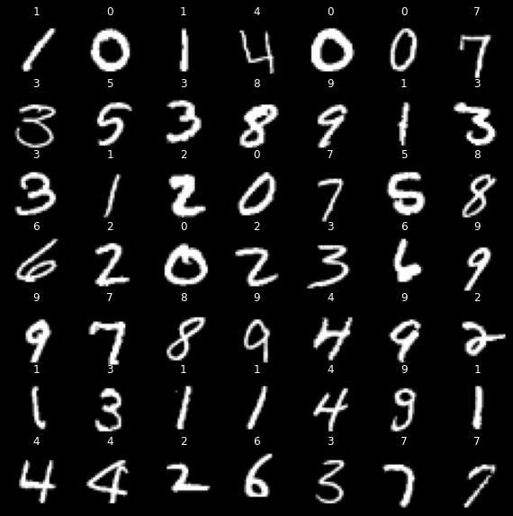

```python
plt.figure(figsize=(10,10))
for i in range(49):
    plt.subplot(7, 7, i+1)
    plt.imshow(X[i,:].reshape(28, 28), cmap='gray')
    plt.title(int(y[i]))
    plt.axis('off')
```

### Plotting Images class wise

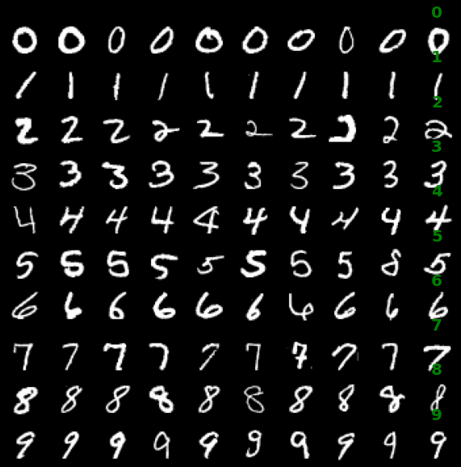

```python
fig,axes = plt.subplots(nrows=10,ncols=10,figsize=(10,10))
for i in range(10):
    nums = df[df['label'] == i]
    X_num = nums.iloc[:, 1:].values
    y_labels = nums.iloc[:,0].values
    for j in range(10):
        axes[i,j].imshow(X_num[j,:].reshape(28, 28), cmap='gray')
        axes[i,j].axis('off')
    axes[i,j].set_title(int(y_labels[i*10+j]), fontdict={'fontsize':20,
                                                          'fontweight':'bold',
                                                          'color':'green'})
```

Even with just the 10 samples, you can see that recognizing the digit is not very easy task. Some of them are so badly written that even a human will have problem understanding.

### Preparing The Dataset

```python
X_train, X_test, y_train, y_test = train_test_split(X, y, test_size=0.1, random_state=42)
X_train.shape, X_test.shape, y_train.shape, y_test.shape
```

```
((37800, 784), (4200, 784), (37800, 1), (4200, 1))
```

```python
X_train = X_train/255.
X_test = X_test/255.
y_train = y_train.ravel()
y_test = y_test.ravel()
y_train.shape, y_test.shape
```

```
((37800,), (4200,))
```

## Modeling

### Non-Nueral Networks

```python
n = Notification()
```

#### Linear Model

```python
classifier = LogisticRegression(random_state=42, solver='lbfgs', multi_class='ovr', max_iter = 1000)
classifier.fit(X_train, y_train)
train_acc = classifier.score(X_train, y_train)
test_acc = classifier.score(X_test, y_test)

text = f"""Model training done. Here are the results:
\tTest Accuracy: {test_acc}
\tTraning Accuracy: {train_acc}"""
```

```python
print(text)
```

```
Model training done. Here are the results:
	Test Accuracy: 0.9102380952380953
	Traning Accuracy: 0.9315343915343915
```

```python
y_pred = classifier.predict(X_test)
print(classification_report(y_test, y_pred))
```

```
              precision    recall  f1-score   support

           0       0.95      0.98      0.97       408
           1       0.96      0.98      0.97       471
           2       0.91      0.89      0.90       420
           3       0.89      0.86      0.87       506
           4       0.91      0.93      0.92       397
           5       0.85      0.87      0.86       339
           6       0.95      0.94      0.94       402
           7       0.92      0.90      0.91       438
           8       0.88      0.85      0.87       403
           9       0.88      0.89      0.89       416

    accuracy                           0.91      4200
   macro avg       0.91      0.91      0.91      4200
weighted avg       0.91      0.91      0.91      4200
```

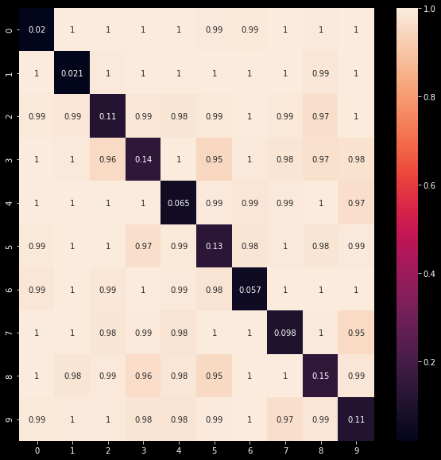

```python
cm = confusion_matrix(y_test, y_pred)
plt.figure(figsize=(10,10))
sns.heatmap(1- cm/cm.sum(axis=1), annot=True);
```

Even a linear model is doing very good. Note that the places where the model has made more mistakes, it has misunderstood between

- 3 and 5
- 3 and 2
- 8 and 5
- 7 and 9 This was expected as these number are very similar when written.

#### Random Forest

```python
rfc = RandomForestClassifier(n_estimators=300, random_state=42)
rfc.fit(X_train, y_train)
```

```
RandomForestClassifier(n_estimators=300, random_state=42)
```

```python
train_acc = rfc.score(X_train, y_train)
test_acc = rfc.score(X_test, y_test)

text = f"""Model training done. Here are the results:
\tTest Accuracy: {test_acc}
\tTraning Accuracy: {train_acc}"""
print(text)
```

```
Model training done. Here are the results:
	Test Accuracy: 0.9654761904761905
	Traning Accuracy: 1.0
```

Performance is better, but there is definetly overfitting occuring. We can try normalization techniques.

#### Gradient Boost Classifier

```python
gbc = GradientBoostingClassifier(random_state=42)
gbc.fit(X_train, y_train)
```

```python
train_acc = gbc.score(X_train, y_train)
test_acc = gbc.score(X_test, y_test)

text = f"""Model training done. Here are the results:
\tTest Accuracy: {test_acc}
\tTraning Accuracy: {train_acc}"""
print(text)
```

```
Model training done. Here are the results:
	Test Accuracy: 0.9416666666666667
	Traning Accuracy: 0.9671428571428572
```

The accuracy is lower than the RandomForest but the model is not overfitting so we can, in principle, increase the accuracy by tuning parameter.

#### XGBOOST

```python
xgbc = XGBClassifier(random_state=42)
xgbc.fit(X_train, y_train)
n.play_n_stop(5)
```

[output not shown]

```python
train_acc = xgbc.score(X_train, y_train)
test_acc = xgbc.score(X_test, y_test)

text = f"""Model training done. Here are the results:
\tTest Accuracy: {test_acc}
\tTraning Accuracy: {train_acc}"""
print(text)
```

```
Model training done. Here are the results:
	Test Accuracy: 0.9761904761904762
	Traning Accuracy: 1.0
```

Okay! About 98% accuracy. However, this is also overfitting.

```python
from sklearn.model_selection import GridSearchCV
```

```python
params = {'n_estimators': [50,100,150],
    'learning_rate': [0.1, 0.4, 0.8],
    'max_depth': [4, 8, 16],
    'min_child_weight': [1, 3, 5],
    'gamma': [0.0, 0.5, 0.9],
    'reg_alpha': [0.0, 0.5, 0.9],
    'reg_lambda': [0.0, 0.5, 0.9],
    'subsample':[0.5, 0.9],
}
xgb_base = XGBClassifier(random_state=101)
gc = GridSearchCV(xgb_base, params, scoring="accuracy")
gc.fit(X_train, y_train, n_jobs = 4, verbose = 4)
```

[output not shown]

[output cut: 58 more lines]

[output not shown]

```python
import sklearn
sorted(sklearn.metrics.SCORERS.keys())
```

```
['accuracy',
 'adjusted_mutual_info_score',
 'adjusted_rand_score',
 'average_precision',
 'balanced_accuracy',
 'completeness_score',
 'explained_variance',
 'f1',
 'f1_macro',
 'f1_micro',
 'f1_samples',
 'f1_weighted',
 'fowlkes_mallows_score',
 'homogeneity_score',
 'jaccard',
 'jaccard_macro',
 'jaccard_micro',
 'jaccard_samples',
 'jaccard_weighted',
 'max_error',
 'mutual_info_score',
 'neg_brier_score',
 'neg_log_loss',
 'neg_mean_absolute_error',
 'neg_mean_gamma_deviance',
 'neg_mean_poisson_deviance',
 'neg_mean_squared_error',
 'neg_mean_squared_log_error',
 'neg_median_absolute_error',
 'neg_root_mean_squared_error',
 'normalized_mutual_info_score',
 'precision',
 'precision_macro',
 'precision_micro',
 'precision_samples',
 'precision_weighted',
 'r2',
 'recall',
 'recall_macro',
 'recall_micro',
 'recall_samples',
 'recall_weighted',
 'roc_auc',
 'roc_auc_ovo',
 'roc_auc_ovo_weighted',
 'roc_auc_ovr',
 'roc_auc_ovr_weighted',
 'v_measure_score']
```

#### ExtraTreesClassifier

```python
extc = ExtraTreesClassifier(random_state=42)
extc.fit(X_train, y_train)

train_acc = extc.score(X_train, y_train)
test_acc = extc.score(X_test, y_test)

text = f"""Model training done. Here are the results:
\tTest Accuracy: {test_acc}
\tTraning Accuracy: {train_acc}"""
print(text)
n.play_n_stop(5)
```

```
Model training done. Here are the results:
	Test Accuracy: 0.9676190476190476
	Traning Accuracy: 1.0
```

Same here!

### Neural Networks

#### Creating Some Callbacks

Since we are going to make a lot of models, we'll set TensorBoard to compare the performance of different models.

```python
def create_tensorboard_callback(experiment_name, dir_name="mnist"):
  log_dir = dir_name + "/" + experiment_name + "/" + datetime.datetime.now().strftime("%Y%m%d-%H%M%S")
  tensorboard_callback = tf.keras.callbacks.TensorBoard(
      log_dir=log_dir
  )
  print(f"Saving TensorBoard log files to: {log_dir}")
  return tensorboard_callback

def create_early_stopping_callback(monitor = 'val_accuracy', patience=5):
  early_stopping_callback = tf.keras.callbacks.EarlyStopping(
      monitor=monitor, patience=patience
  )
  return early_stopping_callback

def create_model_checkpoint(experiment_name, dir_name="mnist_checkpoints",
                            save_freq='epoch', monitor = "val_accuracy"):

  checkpoint_dir = dir_name + "/" + experiment_name
  checkpoint_callback = ModelCheckpoint(
    checkpoint_dir, monitor=monitor, verbose=1, save_best_only=True,
    save_weights_only=False, mode='auto', save_freq=save_freq,
  )
  print(f"Saving model checkpoint to: {checkpoint_dir}")
  return checkpoint_callback
```

#### A Simple NN

We'll start with a simple neural network. Let's make a simple NN without using CNN's.

```python
ohe = OneHotEncoder(sparse=False)
y_train_n = ohe.fit_transform(y_train.reshape(-1, 1))
y_test_n = ohe.fit_transform(y_test.reshape(-1, 1))
```

```python
simplenn = Sequential(name="simplenn")
simplenn.add(tfl.InputLayer(input_shape=(784,), name="input"))
simplenn.add(tfl.Dense(32, activation='relu', name="dense1"))
simplenn.add(tfl.Dense(64, activation='relu', name="dense2"))
simplenn.add(tfl.Dense(128, activation='relu', name="dense3"))
simplenn.add(tfl.Dense(10, activation='softmax', name="output"))

simplenn.summary()
```

```
Model: "simplenn"
_________________________________________________________________
Layer (type)                 Output Shape              Param #
=================================================================
dense1 (Dense)               (None, 32)                25120
_________________________________________________________________
dense2 (Dense)               (None, 64)                2112
_________________________________________________________________
dense3 (Dense)               (None, 128)               8320
_________________________________________________________________
output (Dense)               (None, 10)                1290
=================================================================
Total params: 36,842
Trainable params: 36,842
Non-trainable params: 0
_________________________________________________________________
```

Let's train for 20 epochs.

```python
simplenn.compile(optimizer='adam', loss='categorical_crossentropy',
     metrics=['accuracy'])

history1 = simplenn.fit(X_train, y_train_n, epochs=20, batch_size=128,
               validation_data=(X_test, y_test_n),
               callbacks=[create_tensorboard_callback("simplenn"),
                         create_model_checkpoint("simplenn")
                         ])
```

```
Saving TensorBoard log files to: mnist/simplenn/20220223-122004
Saving model checkpoint to: mnist_checkpoints/simplenn

Epoch 00001: val_accuracy improved from -inf to 0.92333, saving model to mnist_checkpoints\simplenn
INFO:tensorflow:Assets written to: mnist_checkpoints\simplenn\assets

Epoch 00002: val_accuracy improved from 0.92333 to 0.93952, saving model to mnist_checkpoints\simplenn
INFO:tensorflow:Assets written to: mnist_checkpoints\simplenn\assets

Epoch 00003: val_accuracy improved from 0.93952 to 0.94286, saving model to mnist_checkpoints\simplenn
INFO:tensorflow:Assets written to: mnist_checkpoints\simplenn\assets

Epoch 00004: val_accuracy improved from 0.94286 to 0.95429, saving model to mnist_checkpoints\simplenn
INFO:tensorflow:Assets written to: mnist_checkpoints\simplenn\assets

Epoch 00005: val_accuracy did not improve from 0.95429

Epoch 00006: val_accuracy did not improve from 0.95429

Epoch 00007: val_accuracy improved from 0.95429 to 0.96024, saving model to mnist_checkpoints\simplenn
INFO:tensorflow:Assets written to: mnist_checkpoints\simplenn\assets

Epoch 00008: val_accuracy improved from 0.96024 to 0.96286, saving model to mnist_checkpoints\simplenn
INFO:tensorflow:Assets written to: mnist_checkpoints\simplenn\assets

Epoch 00009: val_accuracy did not improve from 0.96286

Epoch 00010: val_accuracy improved from 0.96286 to 0.96452, saving model to mnist_checkpoints\simplenn
INFO:tensorflow:Assets written to: mnist_checkpoints\simplenn\assets

Epoch 00011: val_accuracy did not improve from 0.96452

Epoch 00012: val_accuracy did not improve from 0.96452

Epoch 00013: val_accuracy did not improve from 0.96452

Epoch 00014: val_accuracy did not improve from 0.96452

Epoch 00015: val_accuracy improved from 0.96452 to 0.96548, saving model to mnist_checkpoints\simplenn
INFO:tensorflow:Assets written to: mnist_checkpoints\simplenn\assets

Epoch 00016: val_accuracy improved from 0.96548 to 0.96833, saving model to mnist_checkpoints\simplenn
INFO:tensorflow:Assets written to: mnist_checkpoints\simplenn\assets

Epoch 00017: val_accuracy improved from 0.96833 to 0.96905, saving model to mnist_checkpoints\simplenn
INFO:tensorflow:Assets written to: mnist_checkpoints\simplenn\assets

Epoch 00018: val_accuracy did not improve from 0.96905

Epoch 00019: val_accuracy did not improve from 0.96905

Epoch 00020: val_accuracy did not improve from 0.96905
```

```python
simplenn_best = tf.keras.models.load_model('mnist_checkpoints\simplenn')
simplenn_best.evaluate(X_test, y_test_n)
```

```
[0.12081782519817352, 0.9690476059913635]
```

So, the best accuracy this simple model gives is about 96.9%. Not bad. We can even get better result by running it for a few more epochs. However, the model is overfitting.

Let's make anothor not so simple NN, somewhat deeper before moving to CNNs.

```python
nnmodel = Sequential(
    [
        tfl.InputLayer(input_shape=(784,), name="input"),

        tfl.Dense(32, activation='relu', name="dense1"),
        tfl.BatchNormalization(),
        tfl.Dense(64, activation='relu', name="dense2"),
        tfl.Dropout(0.2),

        tfl.Dense(64, activation='relu', name="dense3"),
        tfl.BatchNormalization(),
        tfl.Dense(128, activation='relu', name="dense4"),
        tfl.Dropout(0.3),

        tfl.Dense(128, activation='relu', name="dense5"),
        tfl.BatchNormalization(),
        tfl.Dense(256, activation='relu', name="dense6"),
        tfl.Dropout(0.4),

        tfl.Dense(10, activation="softmax", name="output")
    ],
    name="non_so_simple_model"
)

nnmodel.summary()
```

```
Model: "non_so_simple_model"
_________________________________________________________________
Layer (type)                 Output Shape              Param #
=================================================================
dense1 (Dense)               (None, 32)                25120
_________________________________________________________________
batch_normalization_3 (Batch (None, 32)                128
_________________________________________________________________
dense2 (Dense)               (None, 64)                2112
_________________________________________________________________
dropout_3 (Dropout)          (None, 64)                0
_________________________________________________________________
dense3 (Dense)               (None, 64)                4160
_________________________________________________________________
batch_normalization_4 (Batch (None, 64)                256
_________________________________________________________________
dense4 (Dense)               (None, 128)               8320
_________________________________________________________________
dropout_4 (Dropout)          (None, 128)               0
_________________________________________________________________
dense5 (Dense)               (None, 128)               16512
_________________________________________________________________
batch_normalization_5 (Batch (None, 128)               512
_________________________________________________________________
dense6 (Dense)               (None, 256)               33024
_________________________________________________________________
dropout_5 (Dropout)          (None, 256)               0
_________________________________________________________________
output (Dense)               (None, 10)                2570
=================================================================
Total params: 92,714
Trainable params: 92,266
Non-trainable params: 448
_________________________________________________________________
```

```python
nnmodel.compile(optimizer='adam', loss='categorical_crossentropy',
     metrics=['accuracy'])

history1 = nnmodel.fit(X_train, y_train_n, epochs=20, batch_size=128,
               validation_data=(X_test, y_test_n),
               callbacks=[create_tensorboard_callback("nnmodel"),
                         create_model_checkpoint("nnmodel")
                         ])
```

```
Saving TensorBoard log files to: mnist/nnmodel/20220223-123944
Saving model checkpoint to: mnist_checkpoints/nnmodel

Epoch 00001: val_accuracy improved from -inf to 0.92071, saving model to mnist_checkpoints\nnmodel
INFO:tensorflow:Assets written to: mnist_checkpoints\nnmodel\assets

Epoch 00002: val_accuracy improved from 0.92071 to 0.94381, saving model to mnist_checkpoints\nnmodel
INFO:tensorflow:Assets written to: mnist_checkpoints\nnmodel\assets

Epoch 00003: val_accuracy improved from 0.94381 to 0.94810, saving model to mnist_checkpoints\nnmodel
INFO:tensorflow:Assets written to: mnist_checkpoints\nnmodel\assets

Epoch 00004: val_accuracy improved from 0.94810 to 0.95214, saving model to mnist_checkpoints\nnmodel
INFO:tensorflow:Assets written to: mnist_checkpoints\nnmodel\assets

Epoch 00005: val_accuracy did not improve from 0.95214

Epoch 00006: val_accuracy improved from 0.95214 to 0.95857, saving model to mnist_checkpoints\nnmodel
INFO:tensorflow:Assets written to: mnist_checkpoints\nnmodel\assets

Epoch 00007: val_accuracy did not improve from 0.95857

Epoch 00008: val_accuracy improved from 0.95857 to 0.96190, saving model to mnist_checkpoints\nnmodel
INFO:tensorflow:Assets written to: mnist_checkpoints\nnmodel\assets

Epoch 00009: val_accuracy did not improve from 0.96190

Epoch 00010: val_accuracy did not improve from 0.96190

Epoch 00011: val_accuracy did not improve from 0.96190

Epoch 00012: val_accuracy did not improve from 0.96190

Epoch 00013: val_accuracy did not improve from 0.96190

Epoch 00014: val_accuracy improved from 0.96190 to 0.96238, saving model to mnist_checkpoints\nnmodel
INFO:tensorflow:Assets written to: mnist_checkpoints\nnmodel\assets

Epoch 00015: val_accuracy improved from 0.96238 to 0.96357, saving model to mnist_checkpoints\nnmodel
INFO:tensorflow:Assets written to: mnist_checkpoints\nnmodel\assets

Epoch 00016: val_accuracy did not improve from 0.96357

Epoch 00017: val_accuracy did not improve from 0.96357

Epoch 00018: val_accuracy did not improve from 0.96357

Epoch 00019: val_accuracy improved from 0.96357 to 0.96405, saving model to mnist_checkpoints\nnmodel
INFO:tensorflow:Assets written to: mnist_checkpoints\nnmodel\assets

Epoch 00020: val_accuracy improved from 0.96405 to 0.96524, saving model to mnist_checkpoints\nnmodel
INFO:tensorflow:Assets written to: mnist_checkpoints\nnmodel\assets
```

```python
nnmodel_best = tf.keras.models.load_model(r'mnist_checkpoints\nnmodel')
nnmodel_best.evaluate(X_test, y_test_n)
```

```
[0.13701382279396057, 0.965238094329834]
```

This model is performing better. Not in terms of accuracy but the fact that the training a test accuracy are close indicates that the model has not overfitted yet. If we train it for a bit longer, we'll definately get better results.

```python
%load_ext tensorboard
%tensorboard --logdir mnist
```

```
The tensorboard extension is already loaded. To reload it, use:
  %reload_ext tensorboard
```

```
Reusing TensorBoard on port 6006 (pid 2220), started 0:05:22 ago. (Use '!kill 2220' to kill it.)
```

[interactive chart not shown]

### Time to train a final model!

**Goal**: Submit only when error on test set is less than 0.05.

```python
n.send_whatsapp_text(f'Training complete')
```

```
SM15bd9bd91c9144729d3ca221a80baa16
```

```python
model = tf.keras.models.load_model('models')
```

```python
model.summary()
```

```
Model: "sequential_12"
_________________________________________________________________
Layer (type)                 Output Shape              Param #
=================================================================
conv2d_51 (Conv2D)           (None, 28, 28, 32)        320
_________________________________________________________________
conv2d_52 (Conv2D)           (None, 28, 28, 32)        9248
_________________________________________________________________
max_pooling2d_29 (MaxPooling (None, 14, 14, 32)        0
_________________________________________________________________
conv2d_53 (Conv2D)           (None, 14, 14, 64)        18496
_________________________________________________________________
conv2d_54 (Conv2D)           (None, 14, 14, 64)        36928
_________________________________________________________________
max_pooling2d_30 (MaxPooling (None, 7, 7, 64)          0
_________________________________________________________________
conv2d_55 (Conv2D)           (None, 7, 7, 128)         73856
_________________________________________________________________
conv2d_56 (Conv2D)           (None, 7, 7, 128)         147584
_________________________________________________________________
max_pooling2d_31 (MaxPooling (None, 3, 3, 128)         0
_________________________________________________________________
flatten_11 (Flatten)         (None, 1152)              0
_________________________________________________________________
dense_22 (Dense)             (None, 128)               147584
_________________________________________________________________
dense_23 (Dense)             (None, 10)                1290
=================================================================
Total params: 435,306
Trainable params: 435,306
Non-trainable params: 0
_________________________________________________________________
```

```python
model = tf.keras.models.load_model("models")
model.evaluate(X_test_n, y_test)
```

```
[0.0376964807510376, 0.9909523725509644]
```

```python
from tensorflow.keras.layers import AveragePooling2D, BatchNormalization, Dropout, Flatten, Dense
```

```python
model2 = Sequential()
model2.add(Conv2D(32, kernel_size=(3, 3), activation='relu', input_shape=(28, 28, 1),
               padding='same')),
model2.add(Conv2D(32, kernel_size=(3, 3), activation='relu',
                  padding='same')),
model2.add(AveragePooling2D(pool_size=(2, 2)))
model2.add(BatchNormalization())
model2.add(Dropout(0.2))

model2.add(Conv2D(64, kernel_size=(3, 3), activation='relu', padding='same'))
model2.add(Conv2D(64, kernel_size=(3, 3), activation='relu', padding='same'))
model2.add(AveragePooling2D(pool_size=(2, 2)))
model2.add(BatchNormalization())

model2.add(Dropout(0.3))
model2.add(Conv2D(128, kernel_size=(3, 3), activation='relu' , padding='same'))
model2.add(Conv2D(128, kernel_size=(3, 3), activation='relu' , padding='same'))
model2.add(AveragePooling2D(pool_size=(2, 2)))
model2.add(BatchNormalization())

model2.add(Flatten())
model2.add(Dropout(0.3))
model2.add(Dense(128, activation='relu'))
model2.add(Dense(10, activation='softmax'))

model2.compile(optimizer='adam', loss='sparse_categorical_crossentropy',
    metrics=['accuracy'])

model2.summary()
```

```
Model: "sequential"
_________________________________________________________________
Layer (type)                 Output Shape              Param #
=================================================================
conv2d (Conv2D)              (None, 28, 28, 32)        320
_________________________________________________________________
conv2d_1 (Conv2D)            (None, 28, 28, 32)        9248
_________________________________________________________________
average_pooling2d (AveragePo (None, 14, 14, 32)        0
_________________________________________________________________
batch_normalization (BatchNo (None, 14, 14, 32)        128
_________________________________________________________________
dropout (Dropout)            (None, 14, 14, 32)        0
_________________________________________________________________
conv2d_2 (Conv2D)            (None, 14, 14, 64)        18496
_________________________________________________________________
conv2d_3 (Conv2D)            (None, 14, 14, 64)        36928
_________________________________________________________________
average_pooling2d_1 (Average (None, 7, 7, 64)          0
_________________________________________________________________
batch_normalization_1 (Batch (None, 7, 7, 64)          256
_________________________________________________________________
dropout_1 (Dropout)          (None, 7, 7, 64)          0
_________________________________________________________________
conv2d_4 (Conv2D)            (None, 7, 7, 128)         73856
_________________________________________________________________
conv2d_5 (Conv2D)            (None, 7, 7, 128)         147584
_________________________________________________________________
average_pooling2d_2 (Average (None, 3, 3, 128)         0
_________________________________________________________________
batch_normalization_2 (Batch (None, 3, 3, 128)         512
_________________________________________________________________
flatten (Flatten)            (None, 1152)              0
_________________________________________________________________
dropout_2 (Dropout)          (None, 1152)              0
_________________________________________________________________
dense (Dense)                (None, 128)               147584
_________________________________________________________________
dense_1 (Dense)              (None, 10)                1290
=================================================================
Total params: 436,202
Trainable params: 435,754
Non-trainable params: 448
_________________________________________________________________
```

```python
history_4 = model2.fit(X_train, y_train, epochs=100, validation_data=(X_test, y_test),
        callbacks=[mch])
```

[output not shown]

[output cut: 43 more lines]

[output not shown]